# Hito 1

Vicente Lepe

Carlo Merino

Cristopher Urbina

María Jesús Vargas

Rocío Yáñez

2022-09-26

# **Estudio de calidad de cervezas**

## **Base de Datos**

Base de Datos escogida y descargada de Kaggle, en: https://www.kaggle.com/datasets/rdoume/beerreviews?resource=download

### **Motivación**

La cerveza es quizás una de las bebidas sociales más antiguas que existe, cuyo nacimiento se estima en la zona de la Mesopotamia del Oriente Medio.

Durante las últimas décadas esta bebida se popularizó a nivel internacional, motivando a personas a emprender en el rubro y adentrarse en la búsqueda de nuevos sabores y aromas, siendo su preparación una actividad artesanal, lo cual entrega valor al producto final.

Dado lo anterior, el conjunto de datos escogidos puede ayudar a una persona que quiere empezar a emprender en este rubro y responder algunas de sus dudas básicas, en particular, el objetivo de esta investigación es responder a la pregunta ¿la calidad de las cervezas se relaciona con la variedad ofrecidas por las cervecerías? Con lo que una emprendedora o emprendedor podría decidir si es más conveniente anteponer la calidad a la variedad o viceversa.

### **Exploración de datos**

A continuación se presenta un primer acercamiento al dataset escogido, el cual consta de 1.586.614 filas y 13 columnas, correspondiendo cada fila al review de una persona para cada cerveza en particular y cada columna a datos referentes a la evaluación o a dicha cerveza en sí.

Las columnas corresponden a:

- **brewery_id:** código de identificación relacionado a una cervecería en particular.
- **brewery_name:** nombre de la cervecería que ha fabricado la cerveza.
- **review_time:** momento en que fue realizada la evaluación de la cerveza.
- **review_overall:** evaluación general de la cerveza.
- **review_aroma:** evaluación con respecto al aroma de la cerveza.
- **review_appearance:** evaluación con respecto a la apariencia de la cerveza.
- **review_profilename:** nombre del perfil del catador de cerveza que realizó la presente evaluación.
- **beer_style:** tipo de cerveza evaluada.
- **review_palate:** evaluación con respecto a la textura de la cerveza.
- **review_taste:** evaluación con respecto al sabor de la cerveza evaluada.
- **beer_name:** nombre de la cerveza evaluada.
- **beer_abv:** grado alcohólico de la cerveza evaluada.
- **beer_beerid:** código de identificación de la cerveza evaluada.

Para conocer información general, desplegamos lo siguiente:

```r
beer<- read.csv(file="/Users/jesuvt/Downloads/beer_reviews.csv", header=TRUE)
head(beer)
```

```
##   brewery_id            brewery_name review_time review_overall review_aroma
## 1      10325         Vecchio Birraio  1234817823            1.5          2.0
## 2      10325         Vecchio Birraio  1235915097            3.0          2.5
## 3      10325         Vecchio Birraio  1235916604            3.0          2.5
## 4      10325         Vecchio Birraio  1234725145            3.0          3.0
## 5       1075 Caldera Brewing Company  1293735206            4.0          4.5
## 6       1075 Caldera Brewing Company  1325524659            3.0          3.5
##   review_appearance review_profilename                     beer_style
## 1               2.5            stcules                     Hefeweizen
## 2               3.0            stcules             English Strong Ale
## 3               3.0            stcules         Foreign / Export Stout
## 4               3.5            stcules                German Pilsener
## 5               4.0     johnmichaelsen American Double / Imperial IPA
## 6               3.5            oline73           Herbed / Spiced Beer
##   review_palate review_taste              beer_name beer_abv beer_beerid
## 1           1.5          1.5           Sausa Weizen      5.0       47986
## 2           3.0          3.0               Red Moon      6.2       48213
## 3           3.0          3.0 Black Horse Black Beer      6.5       48215
## 4           2.5          3.0             Sausa Pils      5.0       47969
## 5           4.0          4.5          Cauldron DIPA      7.7       64883
## 6           3.0          3.5    Caldera Ginger Beer      4.7       52159
```

Ahora, se desea conocer de forma más específica, la cantidad de estilos cervezas y la cantidad total de las distintas cervezas por cervecería, guardando la información para el análisis posterior de estos resultados.

```r
###Cantidad de estilos de cervezas
print(paste("Cantidad de cervezas por estilo:", length(unique(beer$beer_style))))
```

```
## [1] "Cantidad de cervezas por estilo: 104"
```

```r
##Cantidad de cervecerias
print(paste("Cantidad de cervezas por cervecería:", length(unique(beer$brewery_name))))
```

```
## [1] "Cantidad de cervezas por cervecería: 5743"
```

```r
##Cantidad de cervezas producidas por estilo de cerveza
Cantidad_estilos<- setNames(aggregate(beer$brewery_name~beer$beer_style,beer, function(x) length(unique(x))),c("Estilo de cerveza","Cantidad de cervezas"))

##Cantidad de cervezas producidas por cada cerveceria
Cantidad_cervezas_por_cerveceria<- setNames(aggregate(beer$beer_style,by = list(beer$brewery_name),FUN=length),c("Cervecería","Cantidad de cervezas"))
```

#### **Valores nulos**

Se procede a descartar la existencia de valores nulos en cada columna:

```r
#análisis de valores nulos
print(paste("id_cervecería:",anyNA.data.frame(beer$brewery_id)))
```

```
## [1] "id_cervecería: FALSE"
```

```r
print(paste("cervecería:",anyNA.data.frame(beer$brewery_name)))
```

```
## [1] "cervecería: FALSE"
```

```r
print(paste("tiempo:",anyNA.data.frame(beer$review_time)))
```

```
## [1] "tiempo: FALSE"
```

```r
print(paste("evaluacion_general:",anyNA.data.frame(beer$review_overall)))
```

```
## [1] "evaluacion_general: FALSE"
```

```r
print(paste("aroma:",anyNA.data.frame(beer$review_aroma)))
```

```
## [1] "aroma: FALSE"
```

```r
print(paste("apariencia:",anyNA.data.frame(beer$review_appearence)))
```

```
## [1] "apariencia: FALSE"
```

```r
print(paste("catador:",anyNA.data.frame(beer$review_profilename)))
```

```
## [1] "catador: FALSE"
```

```r
print(paste("estilo:",anyNA.data.frame(beer$beer_style)))
```

```
## [1] "estilo: FALSE"
```

```r
print(paste("textura:",anyNA.data.frame(beer$review_palate)))
```

```
## [1] "textura: FALSE"
```

```r
print(paste("sabor:",anyNA.data.frame(beer$review_taste)))
```

```
## [1] "sabor: FALSE"
```

```r
print(paste("nombre:",anyNA.data.frame(beer$beer_name)))
```

```
## [1] "nombre: FALSE"
```

```r
print(paste("alcohol:",anyNA.data.frame(beer$beer_abv)))
```

```
## [1] "alcohol: TRUE"
```

```r
print(paste("id_cerveza:",anyNA.data.frame(beer$beer_id)))
```

```
## [1] "id_cerveza: FALSE"
```

Se tiene que solamente en grado alcohólico existen valores nulos, por lo que se procede a contar cuántos hay en total.

```r
print(paste(sum(is.na(beer$beer_abv))))
```

```
## [1] "67785"
```

Siendo alrededor de 67k valores nulos en grado alcohólico, lo cual se considerará para análisis posteriores, sin realizar eliminación ni reeemplazo de estos valores dada la intención del estudio que deseamo realizar hacia adelante ya que no afecta directamente tener nulos en grados alcohólicos.

#### **Gráficos para el entendimiento visual y correlaciones**

En primera instancia se plotean la cantidad de estilos de cervezas producidas en orden ascendente.

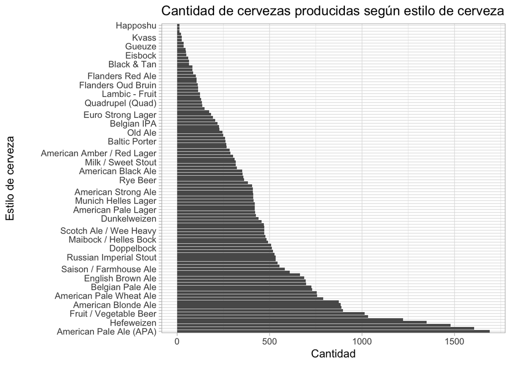

```r
library(ggplot2)
ggplot(data=Cantidad_estilos, aes(x=`Cantidad de cervezas`, y=reorder(`Estilo de cerveza`,-`Cantidad de cervezas`))) +
    geom_bar(stat="identity", position=position_dodge())+
    labs(x="Cantidad", y="Estilo de cerveza")+
    ggtitle("Cantidad de cervezas producidas según estilo de cerveza")+
    guides( y = guide_axis(check.overlap = 2)) +
  theme(axis.text.x = element_text(angle = -45, vjust = 1, hjust=-0.3)) +
  theme_light() +
  theme(legend.position = "topleft")
```

Aquí se puede ver claramente la frecuencia más significativa para la cerveza más producida: American Pale Ale (APA), con una diferencia notoria ante la menos producida: Happoshu.

Luego, se revisan las distintas notas para cada cerveza, y así entender los resultados que se obtendrán al sacar correlación entre nota y general y demás.

```r
#Todas las distintas notas generales para cada cerveza.
unique(beer$review_overall)
```

```
##  [1] 1.5 3.0 4.0 3.5 4.5 5.0 2.0 2.5 1.0 0.0
```

```r
# Todas las distintas notas de aromas de cada cerveza
unique(beer$review_aroma)
```

```
## [1] 2.0 2.5 3.0 4.5 3.5 5.0 4.0 1.5 1.0
```

```r
# Todas las distintas notas de paladar de cada cerveza
unique(beer$review_palate)
```

```
## [1] 1.5 3.0 2.5 4.0 2.0 3.5 4.5 5.0 1.0
```

```r
# Todas las distintas notas de sabor de cada cerveza
unique(beer$review_taste)
```

```
## [1] 1.5 3.0 4.5 3.5 4.0 2.5 2.0 5.0 1.0
```

```r
# Todas las distintas notas de aparaciencia de cada cerveza
unique(beer$review_appearance)
```

```
##  [1] 2.5 3.0 3.5 4.0 5.0 4.5 2.0 1.0 1.5 0.0
```

```r
# Correlación entre nota general y demás
cor(beer$review_overall,beer$review_aroma)
```

```
## [1] 0.6160131
```

```r
cor(beer$review_overall,beer$review_palate)
```

```
## [1] 0.7019139
```

```r
cor(beer$review_overall,beer$review_taste)
```

```
## [1] 0.7898156
```

```r
cor(beer$review_overall,beer$review_appearance)
```

```
## [1] 0.5017324
```

De lo anterior, en primera instancia se entiende que las correlaciones entre nota y general y demás, son positivas por lo que tienden a aumentar en forma proporcional, teniendo la correlación entre nota general y nota de sabor con la correlación más fuerte y entre nota general y nota de apariencia con la correlación más débil.

Para finalizar el apartado de gráficos, se obtienen las distribuciones de cada nota.

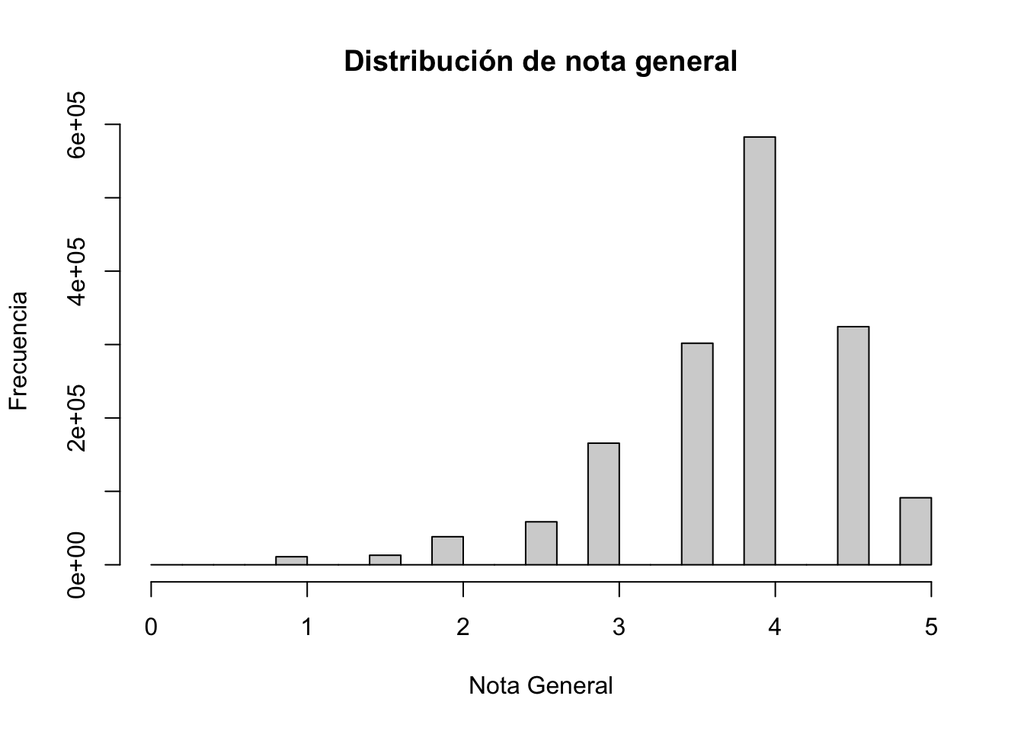

```r
hist(beer$review_overall, xlab = "Nota General", ylab="Frecuencia", main="Distribución de nota general")
```

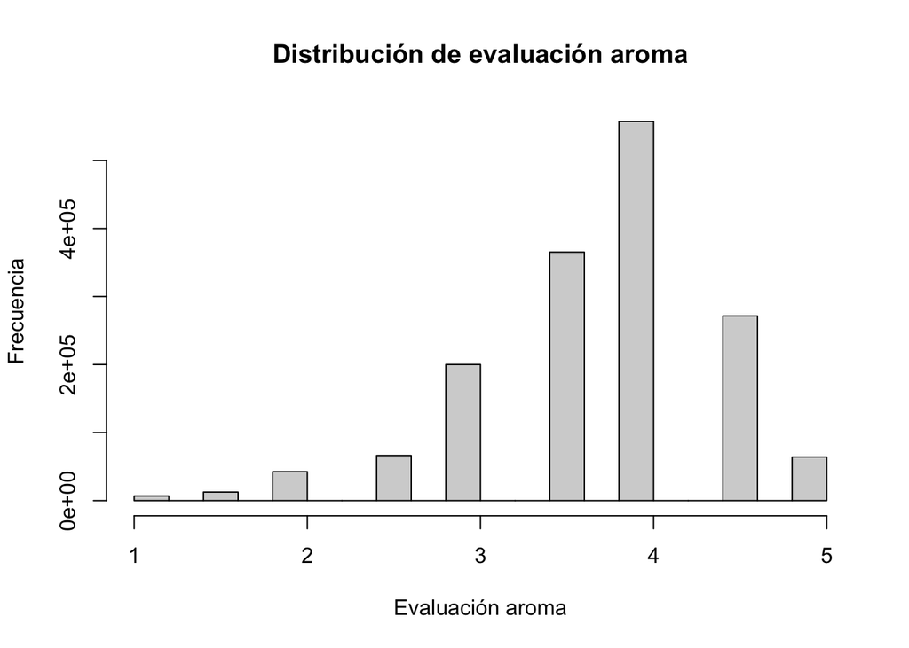

```r
hist(beer$review_aroma, xlab = "Evaluación aroma", ylab="Frecuencia", main="Distribución de evaluación aroma")
```

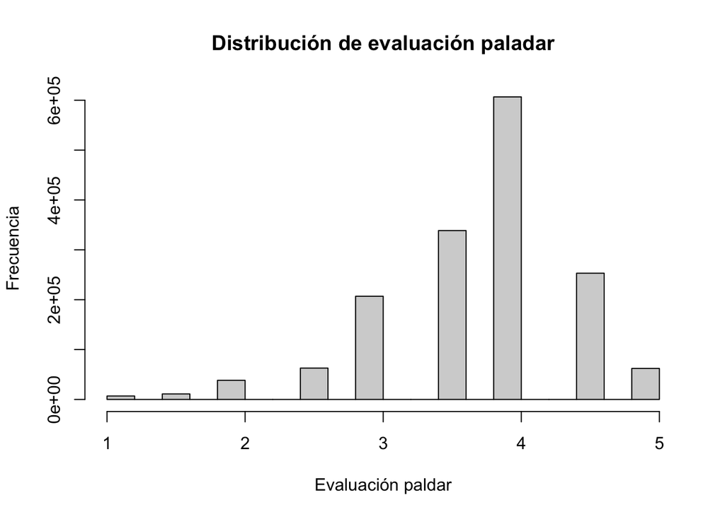

```r
hist(beer$review_palate, xlab = "Evaluación paldar", ylab="Frecuencia", main="Distribución de evaluación paladar")
```

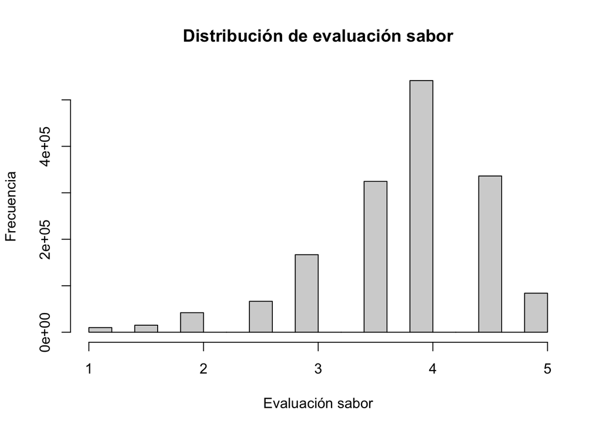

```r
hist(beer$review_taste, xlab = "Evaluación sabor", ylab="Frecuencia", main="Distribución de evaluación sabor")
```

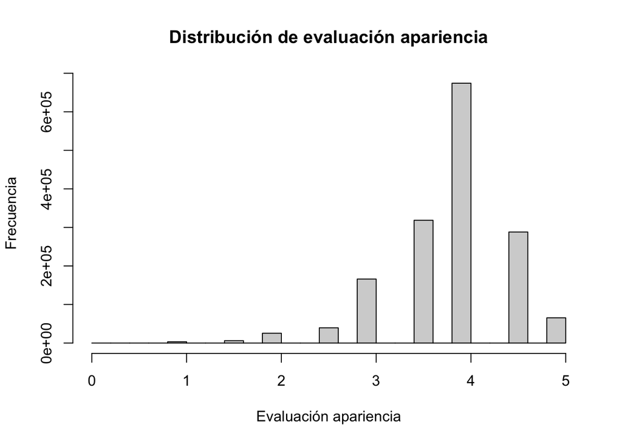

```r
hist(beer$review_appearance, xlab = "Evaluación apariencia", ylab="Frecuencia", main="Distribución de evaluación apariencia")
```

Claramente de lo anterior, se puede ver que todas las notas se encuentran concentradas entre la nota 3 y 5, y probablemente el promedio también se encuentre aquí, lo cual se comprueba en el siguiente análasis estadístico.

```r
summary(beer)
```

```
##    brewery_id    brewery_name        review_time        review_overall
##  Min.   :    1   Length:1586614     Min.   :8.407e+08   Min.   :0.000
##  1st Qu.:  143   Class :character   1st Qu.:1.173e+09   1st Qu.:3.500
##  Median :  429   Mode  :character   Median :1.239e+09   Median :4.000
##  Mean   : 3130                      Mean   :1.224e+09   Mean   :3.816
##  3rd Qu.: 2372                      3rd Qu.:1.289e+09   3rd Qu.:4.500
##  Max.   :28003                      Max.   :1.326e+09   Max.   :5.000
##
##   review_aroma   review_appearance review_profilename  beer_style
##  Min.   :1.000   Min.   :0.000     Length:1586614     Length:1586614
##  1st Qu.:3.500   1st Qu.:3.500     Class :character   Class :character
##  Median :4.000   Median :4.000     Mode  :character   Mode  :character
##  Mean   :3.736   Mean   :3.842
##  3rd Qu.:4.000   3rd Qu.:4.000
##  Max.   :5.000   Max.   :5.000
##
##  review_palate    review_taste    beer_name            beer_abv
##  Min.   :1.000   Min.   :1.000   Length:1586614     Min.   : 0.01
##  1st Qu.:3.500   1st Qu.:3.500   Class :character   1st Qu.: 5.20
##  Median :4.000   Median :4.000   Mode  :character   Median : 6.50
##  Mean   :3.744   Mean   :3.793                      Mean   : 7.04
##  3rd Qu.:4.000   3rd Qu.:4.500                      3rd Qu.: 8.50
##  Max.   :5.000   Max.   :5.000                      Max.   :57.70
##                                                     NA's   :67785
##   beer_beerid
##  Min.   :    3
##  1st Qu.: 1717
##  Median :13906
##  Mean   :21713
##  3rd Qu.:39441
##  Max.   :77317
##
```

Los promedios de las notas, se encuentran principalmente entre 3 y 4.

#### **Outliers**

A continuación, se reconocerán y analizarán valores atípicos, para nota general y grados alcohólicos:

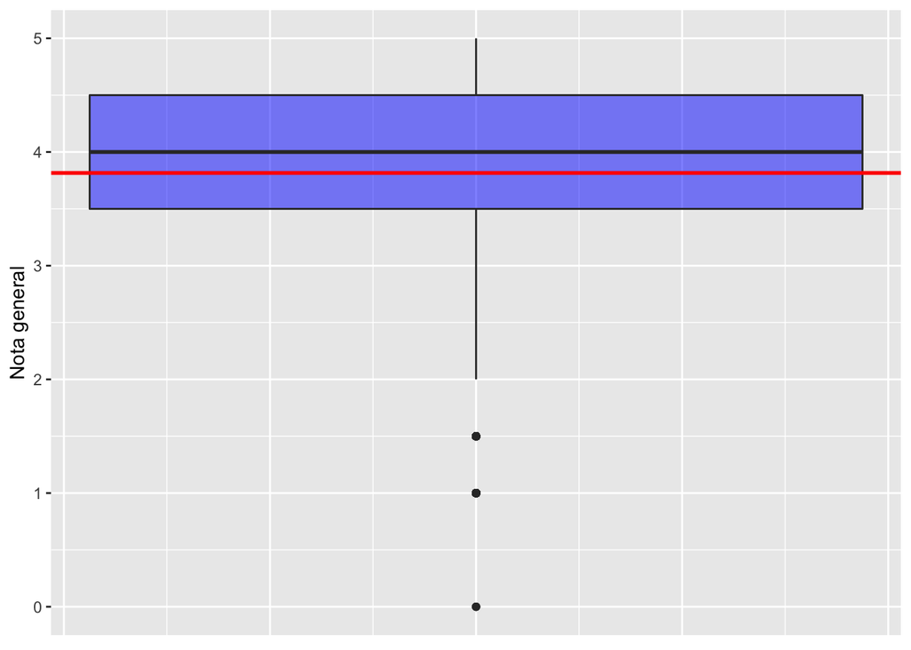

```r
ggplot(beer)+
  aes(y=review_overall)+
  geom_boxplot(fill="blue",alpha=0.5)+
  theme(axis.title.x=element_blank(),   #En estas 3 líneas sacamos todo lo que surge del eje x,
        axis.text.x=element_blank(),    #pues en los boxplot solo tenemos info en el eje y
        axis.ticks.x=element_blank())+
  ylab("Nota general")+
  geom_hline(aes(yintercept = mean(review_overall)),col='red',size=1)
```

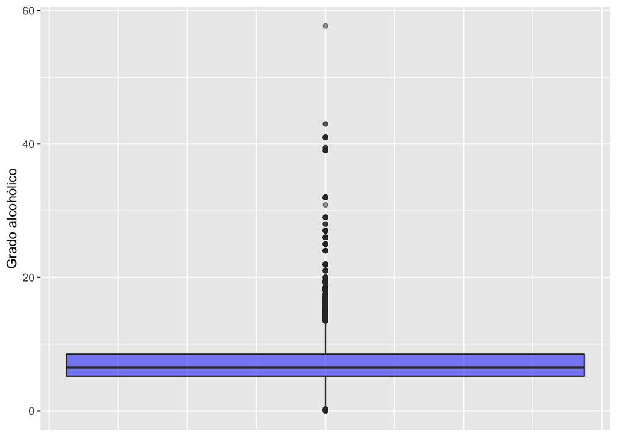

```r
ggplot(beer)+
  aes(y=beer_abv)+
  geom_boxplot(fill="blue",alpha=0.5)+
  theme(axis.title.x=element_blank(),   #En estas 3 líneas sacamos todo lo que surge del eje x,
        axis.text.x=element_blank(),    #pues en los boxplot solo tenemos info en el eje y
        axis.ticks.x=element_blank())+
  ylab("Grado alcohólico")+
  geom_hline(aes(yintercept = mean(beer_abv)),col='red',size=1)
```

Finalmente, se reconoce que en grados alcohólicos podrían exisitir outliers, pero se confirma que son reamlente los grados correspondientes a cada cerveza con un máximo de 57,7º. Por lo tanto, no se realizará la eliminación de ningún dato.

**A modo de conclusión, luego de todo el análisis previo; la base de datos se encuentra en buen estado para continuar con el estudio posterior.**